# project_2_eda

Blake Armstrong and Eric Graham

2025-08-02

# 1: Setup

```r
df = read.csv2("bank-additional-full.csv", header = TRUE)
names(df)
```

```
##  [1] "age"            "job"            "marital"        "education"
##  [5] "default"        "housing"        "loan"           "contact"
##  [9] "month"          "day_of_week"    "duration"       "campaign"
## [13] "pdays"          "previous"       "poutcome"       "emp.var.rate"
## [17] "cons.price.idx" "cons.conf.idx"  "euribor3m"      "nr.employed"
## [21] "y"
```

```r
str(df)
```

```
## 'data.frame':    41188 obs. of  21 variables:
##  $ age           : int  56 57 37 40 56 45 59 41 24 25 ...
##  $ job           : chr  "housemaid" "services" "services" "admin." ...
##  $ marital       : chr  "married" "married" "married" "married" ...
##  $ education     : chr  "basic.4y" "high.school" "high.school" "basic.6y" ...
##  $ default       : chr  "no" "unknown" "no" "no" ...
##  $ housing       : chr  "no" "no" "yes" "no" ...
##  $ loan          : chr  "no" "no" "no" "no" ...
##  $ contact       : chr  "telephone" "telephone" "telephone" "telephone" ...
##  $ month         : chr  "may" "may" "may" "may" ...
##  $ day_of_week   : chr  "mon" "mon" "mon" "mon" ...
##  $ duration      : int  261 149 226 151 307 198 139 217 380 50 ...
##  $ campaign      : int  1 1 1 1 1 1 1 1 1 1 ...
##  $ pdays         : int  999 999 999 999 999 999 999 999 999 999 ...
##  $ previous      : int  0 0 0 0 0 0 0 0 0 0 ...
##  $ poutcome      : chr  "nonexistent" "nonexistent" "nonexistent" "nonexistent" ...
##  $ emp.var.rate  : chr  "1.1" "1.1" "1.1" "1.1" ...
##  $ cons.price.idx: chr  "93.994" "93.994" "93.994" "93.994" ...
##  $ cons.conf.idx : chr  "-36.4" "-36.4" "-36.4" "-36.4" ...
##  $ euribor3m     : chr  "4.857" "4.857" "4.857" "4.857" ...
##  $ nr.employed   : chr  "5191" "5191" "5191" "5191" ...
##  $ y             : chr  "no" "no" "no" "no" ...
```

```r
head(df)
```

```
##   age       job marital   education default housing loan   contact month
## 1  56 housemaid married    basic.4y      no      no   no telephone   may
## 2  57  services married high.school unknown      no   no telephone   may
## 3  37  services married high.school      no     yes   no telephone   may
## 4  40    admin. married    basic.6y      no      no   no telephone   may
## 5  56  services married high.school      no      no  yes telephone   may
## 6  45  services married    basic.9y unknown      no   no telephone   may
##   day_of_week duration campaign pdays previous    poutcome emp.var.rate
## 1         mon      261        1   999        0 nonexistent          1.1
## 2         mon      149        1   999        0 nonexistent          1.1
## 3         mon      226        1   999        0 nonexistent          1.1
## 4         mon      151        1   999        0 nonexistent          1.1
## 5         mon      307        1   999        0 nonexistent          1.1
## 6         mon      198        1   999        0 nonexistent          1.1
##   cons.price.idx cons.conf.idx euribor3m nr.employed  y
## 1         93.994         -36.4     4.857        5191 no
## 2         93.994         -36.4     4.857        5191 no
## 3         93.994         -36.4     4.857        5191 no
## 4         93.994         -36.4     4.857        5191 no
## 5         93.994         -36.4     4.857        5191 no
## 6         93.994         -36.4     4.857        5191 no
```

# 2: Exploratory Data Analysis

As we see above the Bank Marketing dataset includes 41,188 rows and 21 columns. The dataset contains information about clients of a banking institution and whether they subscribed to a term deposit. To approach the question of “How can we predict whether a client will subscribe to a term deposit?” we will perform exploratory data analysis (EDA) to understand the data, identify patterns, and prepare for modeling.

## Variable Classification and Basic Cleaning

```r
df = df %>% mutate(
  emp.var.rate = as.numeric(emp.var.rate),
  cons.price.idx = as.numeric(cons.price.idx),
  cons.conf.idx = as.numeric(cons.conf.idx),
  euribor3m = as.numeric(euribor3m),
  nr.employed = as.numeric(nr.employed),
  poutcome = as.factor(poutcome),
  y = factor(y, levels = c("no", "yes")),
  pdays_missing = pdays == 999,
  poutcome_missing = poutcome == "nonexistent")
str(df)
```

```
## 'data.frame':    41188 obs. of  23 variables:
##  $ age             : int  56 57 37 40 56 45 59 41 24 25 ...
##  $ job             : chr  "housemaid" "services" "services" "admin." ...
##  $ marital         : chr  "married" "married" "married" "married" ...
##  $ education       : chr  "basic.4y" "high.school" "high.school" "basic.6y" ...
##  $ default         : chr  "no" "unknown" "no" "no" ...
##  $ housing         : chr  "no" "no" "yes" "no" ...
##  $ loan            : chr  "no" "no" "no" "no" ...
##  $ contact         : chr  "telephone" "telephone" "telephone" "telephone" ...
##  $ month           : chr  "may" "may" "may" "may" ...
##  $ day_of_week     : chr  "mon" "mon" "mon" "mon" ...
##  $ duration        : int  261 149 226 151 307 198 139 217 380 50 ...
##  $ campaign        : int  1 1 1 1 1 1 1 1 1 1 ...
##  $ pdays           : int  999 999 999 999 999 999 999 999 999 999 ...
##  $ previous        : int  0 0 0 0 0 0 0 0 0 0 ...
##  $ poutcome        : Factor w/ 3 levels "failure","nonexistent",..: 2 2 2 2 2 2 2 2 2 2 ...
##  $ emp.var.rate    : num  1.1 1.1 1.1 1.1 1.1 1.1 1.1 1.1 1.1 1.1 ...
##  $ cons.price.idx  : num  94 94 94 94 94 ...
##  $ cons.conf.idx   : num  -36.4 -36.4 -36.4 -36.4 -36.4 -36.4 -36.4 -36.4 -36.4 -36.4 ...
##  $ euribor3m       : num  4.86 4.86 4.86 4.86 4.86 ...
##  $ nr.employed     : num  5191 5191 5191 5191 5191 ...
##  $ y               : Factor w/ 2 levels "no","yes": 1 1 1 1 1 1 1 1 1 1 ...
##  $ pdays_missing   : logi  TRUE TRUE TRUE TRUE TRUE TRUE ...
##  $ poutcome_missing: logi  TRUE TRUE TRUE TRUE TRUE TRUE ...
```

Aside from some basic datatype conversions, the dataset glossary shows that the value “999” designates that the client was not previously contacted. Thus, we create a new boolean variable `pdays_missing` to indicate whether the `pdays` value is 999.

You would expect that this would match up with the number of “nonexistent” results on the poutcome variable, which indicates the outcome of prior marketing attempts. However, that is not the case:

```r
table(df$pdays_missing, df$poutcome_missing)
```

```
##
##         FALSE  TRUE
##   FALSE  1515     0
##   TRUE   4110 35563
```

We see 4110 records for which the pdays value was 999, but the prior outcome is not flagged as “nonexistent.”

```r
df %>%
  filter(pdays_missing) %>%
  group_by(poutcome) %>%
  summarize(count = n())
```

```
## # A tibble: 2 × 2
##   poutcome    count
##   <fct>       <int>
## 1 failure      4110
## 2 nonexistent 35563
```

This is contradictory: the poutcome values here imply that the client was previously contacted, and that the attempt failed, but the pdays value indicates that the client was never contacted. This is a data quality issue that we will need to address in our analysis.

```r
target_var = "y"

num_vars = df %>% select(where(is.numeric)) %>% names()
num_vars = setdiff(num_vars, target_var)

cat_vars = setdiff(names(df), c(num_vars, target_var))
cat_vars
```

```
##  [1] "job"              "marital"          "education"        "default"
##  [5] "housing"          "loan"             "contact"          "month"
##  [9] "day_of_week"      "poutcome"         "pdays_missing"    "poutcome_missing"
```

```r
# num_vars
```

```r
# head(df)
# glimpse(df)
skim(df)
```

Data summary

| Name | df |
| --- | --- |
| Number of rows | 41188 |
| Number of columns | 23 |
| _______________________ |  |
| Column type frequency: |  |
| character | 9 |
| factor | 2 |
| logical | 2 |
| numeric | 10 |
| ________________________ |  |
| Group variables | None |

**Variable type: character**

| skim_variable | n_missing | complete_rate | min | max | empty | n_unique | whitespace |
| --- | --- | --- | --- | --- | --- | --- | --- |
| job | 0 | 1 | 6 | 13 | 0 | 12 | 0 |
| marital | 0 | 1 | 6 | 8 | 0 | 4 | 0 |
| education | 0 | 1 | 7 | 19 | 0 | 8 | 0 |
| default | 0 | 1 | 2 | 7 | 0 | 3 | 0 |
| housing | 0 | 1 | 2 | 7 | 0 | 3 | 0 |
| loan | 0 | 1 | 2 | 7 | 0 | 3 | 0 |
| contact | 0 | 1 | 8 | 9 | 0 | 2 | 0 |
| month | 0 | 1 | 3 | 3 | 0 | 10 | 0 |
| day_of_week | 0 | 1 | 3 | 3 | 0 | 5 | 0 |

**Variable type: factor**

| skim_variable | n_missing | complete_rate | ordered | n_unique | top_counts |
| --- | --- | --- | --- | --- | --- |
| poutcome | 0 | 1 | FALSE | 3 | non: 35563, fai: 4252, suc: 1373 |
| y | 0 | 1 | FALSE | 2 | no: 36548, yes: 4640 |

**Variable type: logical**

| skim_variable | n_missing | complete_rate | mean | count |
| --- | --- | --- | --- | --- |
| pdays_missing | 0 | 1 | 0.96 | TRU: 39673, FAL: 1515 |
| poutcome_missing | 0 | 1 | 0.86 | TRU: 35563, FAL: 5625 |

**Variable type: numeric**

| skim_variable | n_missing | complete_rate | mean | sd | p0 | p25 | p50 | p75 | p100 | hist |
| --- | --- | --- | --- | --- | --- | --- | --- | --- | --- | --- |
| age | 0 | 1 | 40.02 | 10.42 | 17.00 | 32.00 | 38.00 | 47.00 | 98.00 | ▅▇▃▁▁ |
| duration | 0 | 1 | 258.29 | 259.28 | 0.00 | 102.00 | 180.00 | 319.00 | 4918.00 | ▇▁▁▁▁ |
| campaign | 0 | 1 | 2.57 | 2.77 | 1.00 | 1.00 | 2.00 | 3.00 | 56.00 | ▇▁▁▁▁ |
| pdays | 0 | 1 | 962.48 | 186.91 | 0.00 | 999.00 | 999.00 | 999.00 | 999.00 | ▁▁▁▁▇ |
| previous | 0 | 1 | 0.17 | 0.49 | 0.00 | 0.00 | 0.00 | 0.00 | 7.00 | ▇▁▁▁▁ |
| emp.var.rate | 0 | 1 | 0.08 | 1.57 | -3.40 | -1.80 | 1.10 | 1.40 | 1.40 | ▁▃▁▁▇ |
| cons.price.idx | 0 | 1 | 93.58 | 0.58 | 92.20 | 93.08 | 93.75 | 93.99 | 94.77 | ▁▆▃▇▂ |
| cons.conf.idx | 0 | 1 | -40.50 | 4.63 | -50.80 | -42.70 | -41.80 | -36.40 | -26.90 | ▅▇▁▇▁ |
| euribor3m | 0 | 1 | 3.62 | 1.73 | 0.63 | 1.34 | 4.86 | 4.96 | 5.04 | ▅▁▁▁▇ |
| nr.employed | 0 | 1 | 5167.04 | 72.25 | 4963.60 | 5099.10 | 5191.00 | 5228.10 | 5228.10 | ▁▁▃▁▇ |

The skim() function provides a summary of the dataset, and we see no missing values.

## Variable Glossary

```r
data.frame(
  Variable_Name = c(
    "Age", "Job", "Marital", "Education", "Default", "Housing", "Loan",
    "Contact", "Month", "Day_of_week", "Duration",
    "Campaign", "Pdays", "Previous", "Poutcome",
    "Emp.var.rate", "Cons.price.idx", "Cons.conf.idx",
    "Euribor3m", "Nr.employed", "y"
  ),
  Description = c(
    "Client age in years",
    "Type of job (e.g., admin., technician, retired, etc.)",
    "Marital status (married, single, divorced/widowed, unknown)",
    "Education level (e.g., basic.4y, high school, university, etc.)",
    "Has credit in default? (yes, no, unknown)",
    "Has housing loan? (yes, no, unknown)",
    "Has personal loan? (yes, no, unknown)",
    "Contact communication type (cellular or telephone)",
    "Last contact month of the year",
    "Last contact day of the week",
    "Last contact duration (in seconds)",
    "Number of contacts during this campaign (includes last contact)",
    "Days since client was last contacted (999 = not previously contacted)",
    "Number of contacts before this campaign",
    "Outcome of the previous marketing campaign",
    "Employment variation rate (quarterly)",
    "Consumer price index (monthly)",
    "Consumer confidence index (monthly)",
    "3-month Euribor rate (daily)",
    "Number of employees (quarterly)",
    "Client subscribed to a term deposit? (yes or no)"
  ),
  `Data Type` = c(
    "integer", "character", "character", "character", "character", "character", "character",
    "character", "character", "character", "integer",
    "integer", "integer", "integer", "factor",
    "numeric", "numeric", "numeric",
    "numeric", "numeric", "factor"
  ),
  Type = c(
    "continuous", "categorical", "categorical", "categorical", "categorical", "categorical", "categorical",
    "categorical", "categorical", "categorical", "continuous",
    "discrete", "discrete", "discrete", "categorical",
    "continuous", "continuous", "continuous",
    "continuous", "continuous", "binary"
  )
) |>
  kable()
```

| Variable_Name | Description | Data.Type | Type |
| --- | --- | --- | --- |
| Age | Client age in years | integer | continuous |
| Job | Type of job (e.g., admin., technician, retired, etc.) | character | categorical |
| Marital | Marital status (married, single, divorced/widowed, unknown) | character | categorical |
| Education | Education level (e.g., basic.4y, high school, university, etc.) | character | categorical |
| Default | Has credit in default? (yes, no, unknown) | character | categorical |
| Housing | Has housing loan? (yes, no, unknown) | character | categorical |
| Loan | Has personal loan? (yes, no, unknown) | character | categorical |
| Contact | Contact communication type (cellular or telephone) | character | categorical |
| Month | Last contact month of the year | character | categorical |
| Day_of_week | Last contact day of the week | character | categorical |
| Duration | Last contact duration (in seconds) | integer | continuous |
| Campaign | Number of contacts during this campaign (includes last contact) | integer | discrete |
| Pdays | Days since client was last contacted (999 = not previously contacted) | integer | discrete |
| Previous | Number of contacts before this campaign | integer | discrete |
| Poutcome | Outcome of the previous marketing campaign | factor | categorical |
| Emp.var.rate | Employment variation rate (quarterly) | numeric | continuous |
| Cons.price.idx | Consumer price index (monthly) | numeric | continuous |
| Cons.conf.idx | Consumer confidence index (monthly) | numeric | continuous |
| Euribor3m | 3-month Euribor rate (daily) | numeric | continuous |
| Nr.employed | Number of employees (quarterly) | numeric | continuous |
| y | Client subscribed to a term deposit? (yes or no) | factor | binary |

## Univariate Analysis

```r
label_dict = c(
  "age" = "Age",
  "job" = "Job",
  "marital" = "Marital Status",
  "education" = "Education",
  "default" = "Default",
  "housing" = "Housing Loan",
  "loan" = "Personal Loan",
  "contact" = "Contact Type",
  "month" = "Month",
  "day_of_week" = "Day of Week",
  "duration" = "Duration",
  "campaign" = "Campaign Contacts",
  "pdays" = "Days Since Last Contact",
  "previous" = "Previous Contacts",
  "poutcome" = "Previous Outcome",
  "emp.var.rate" = "Employment Variation Rate",
  "cons.price.idx" = "Consumer Price Index",
  "cons.conf.idx" = "Consumer Confidence Index",
  "euribor3m" = "Euribor 3 Month Rate",
  "nr.employed" = "Number of Employees",
  "y" = "Subscribed"
)

pretty_var = function(x) {
  gsub("_", " ", tools::toTitleCase(x))
}

get_label = function(varname) {
  if (varname %in% names(label_dict)) {
    return(label_dict[[varname]])
  } else {
    return(pretty_var(varname))
  }
}
```

### Distribution of Response Variable

We see the overwhelming number of clients did not subscribe to a term deposit, with only about 11% of the clients subscribing. This will come as no surprise to those who have ever worked in an outbound call center.

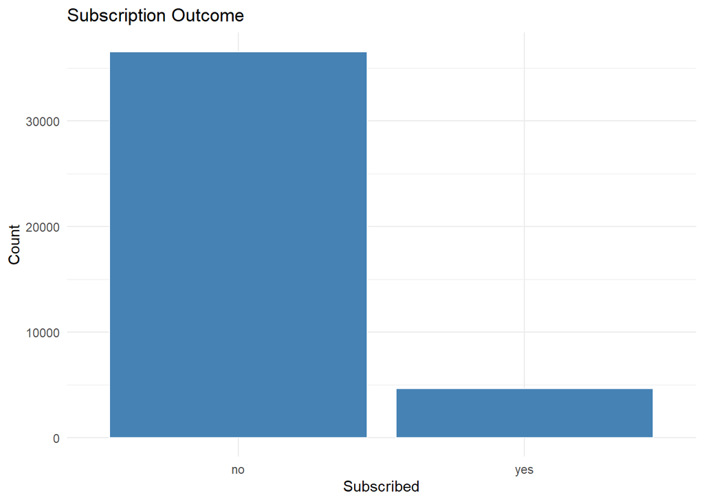

```r
p = ggplot(df, aes(x = y)) +
  geom_bar(fill = "steelblue", color = "white") +
  labs(
    x = "Subscribed",
    y = "Count",
    title = "Subscription Outcome"
  ) +
  theme_minimal()
print(p)
```

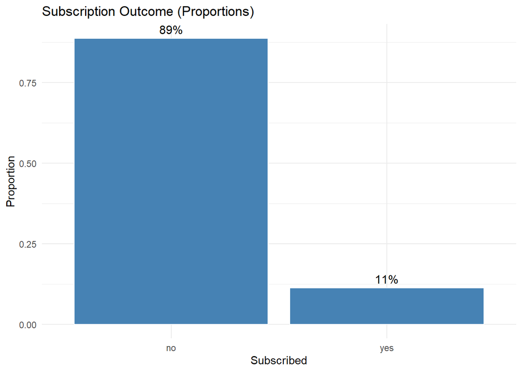

```r
p2 = ggplot(df, aes(x = y)) +
  geom_bar(aes(y = after_stat(prop), group = 1), fill = "steelblue", color = "white") +
  geom_text(
    aes(y = after_stat(prop), label = scales::percent(after_stat(prop)), group = 1),
    stat = "count",
    vjust = -0.5,
    color = "black",
    size = 4
  ) +
  labs(
    x = "Subscribed",
    y = "Proportion",
    title = "Subscription Outcome (Proportions)"
  ) +
  theme_minimal()
print(p2)
```

### Numeric Predictors

**Click to expand: Numeric Variable Plots**

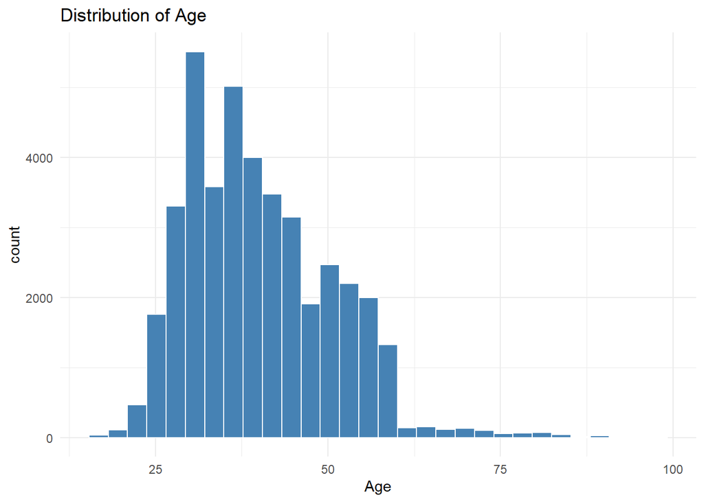

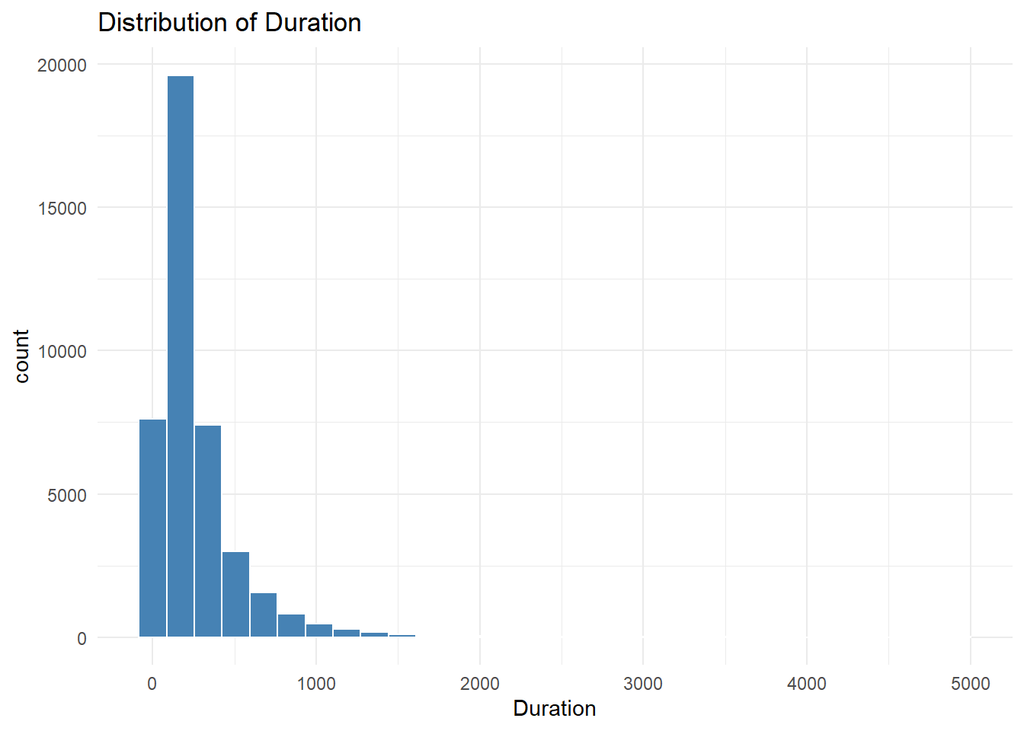

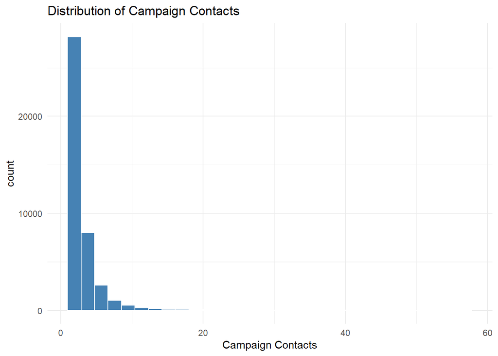

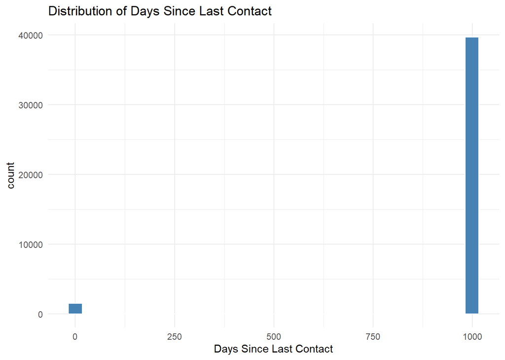

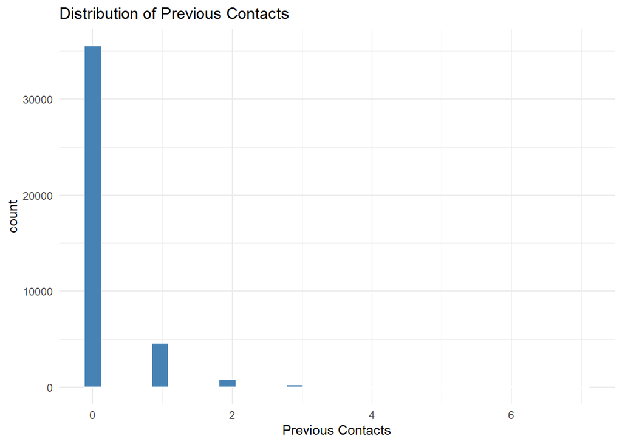

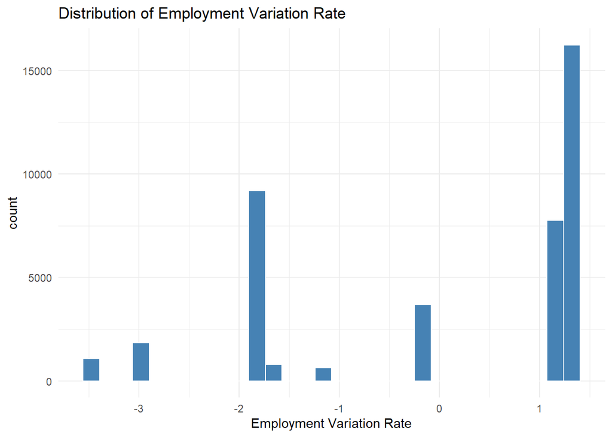

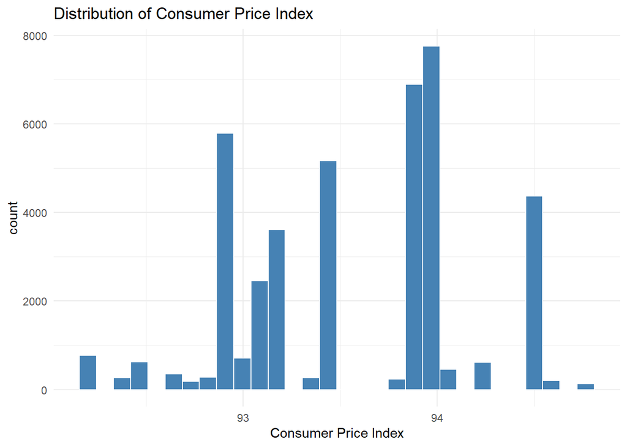

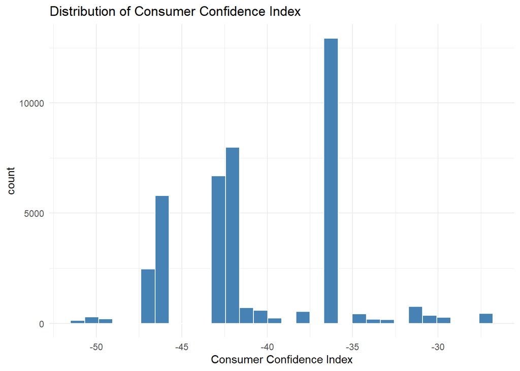

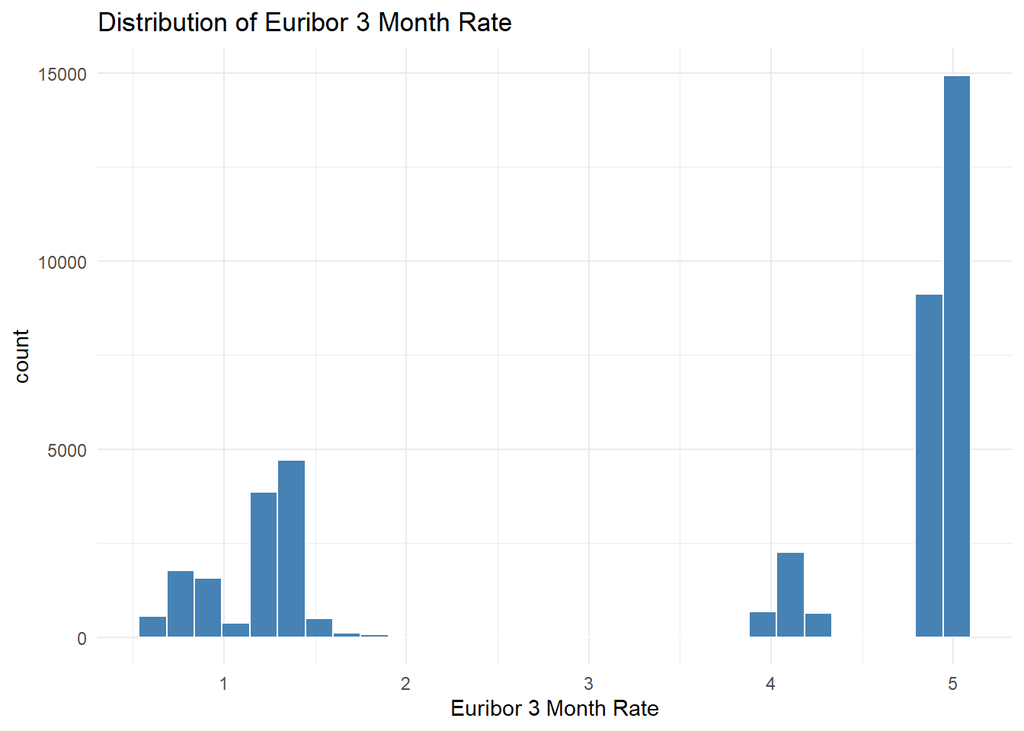

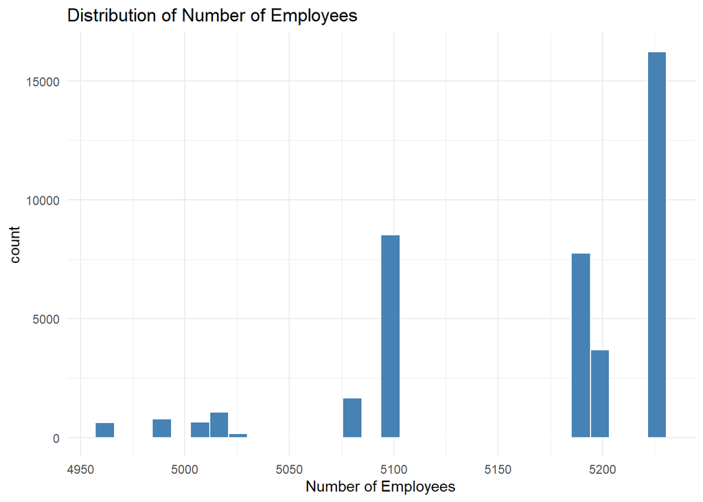

```r
for (var in num_vars) {
  p = ggplot(df, aes(x = !!sym(var))) +
    geom_histogram(fill = "steelblue", color = "white") +
    labs(
      x = get_label(var),
      title = paste("Distribution of", get_label(var))
    ) +
    theme_minimal()
  print(p)
}
```

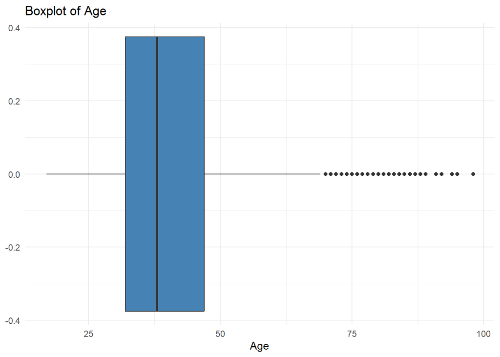

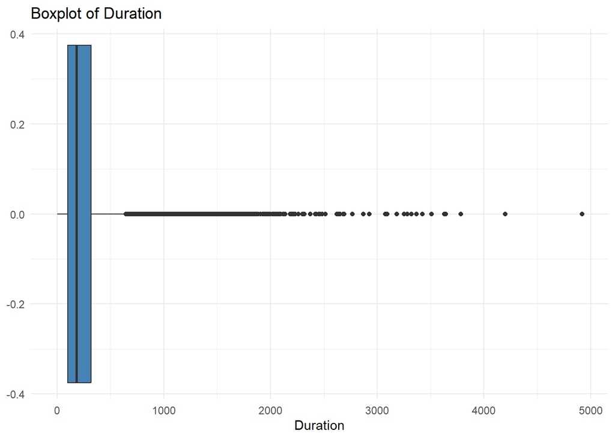

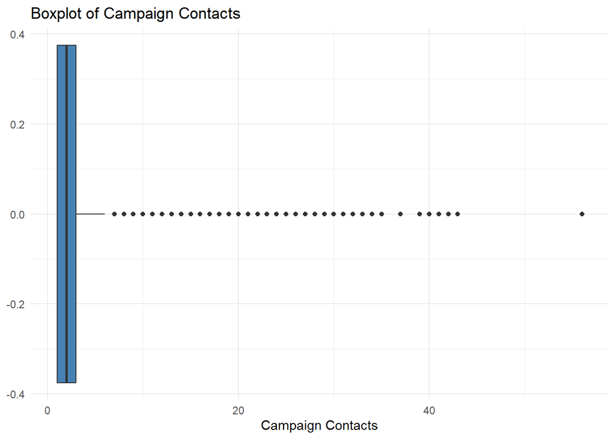

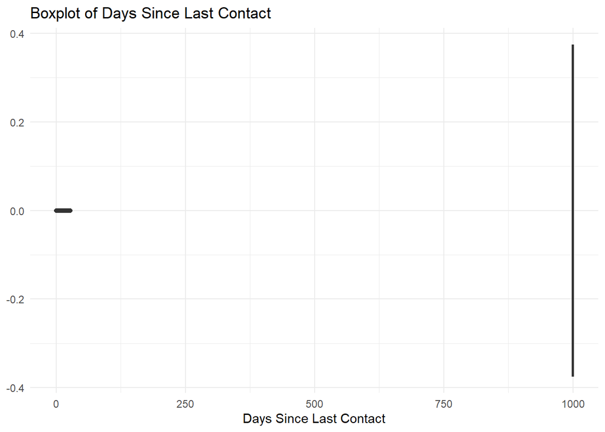

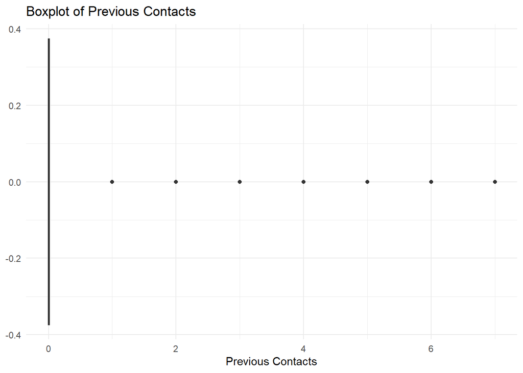

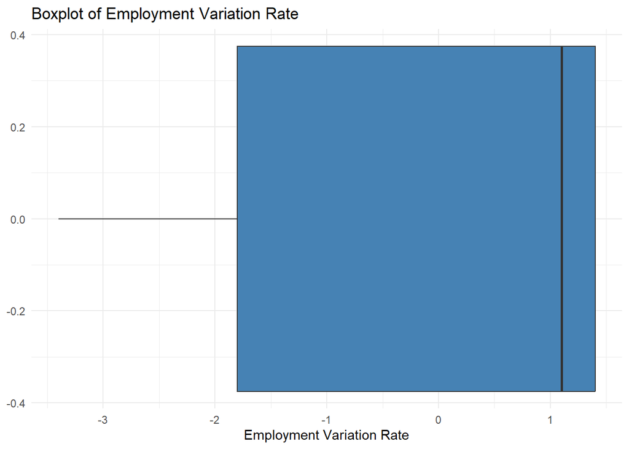

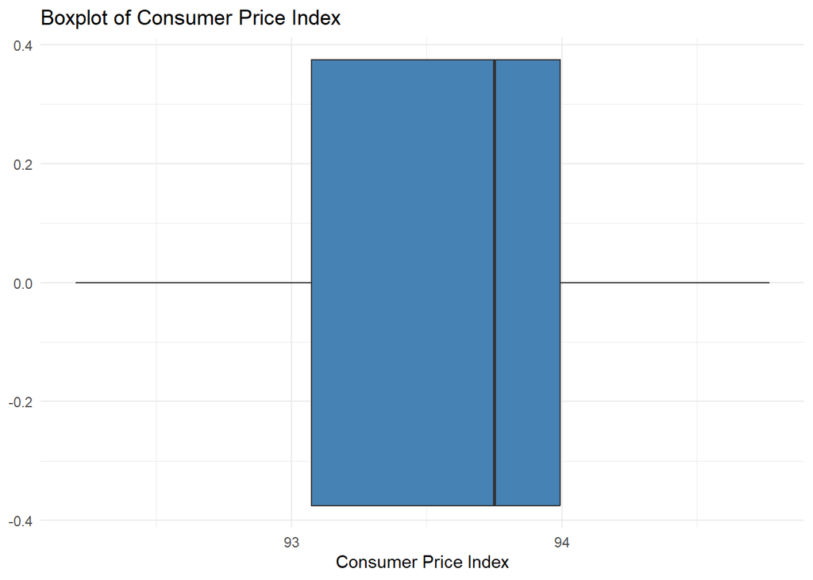

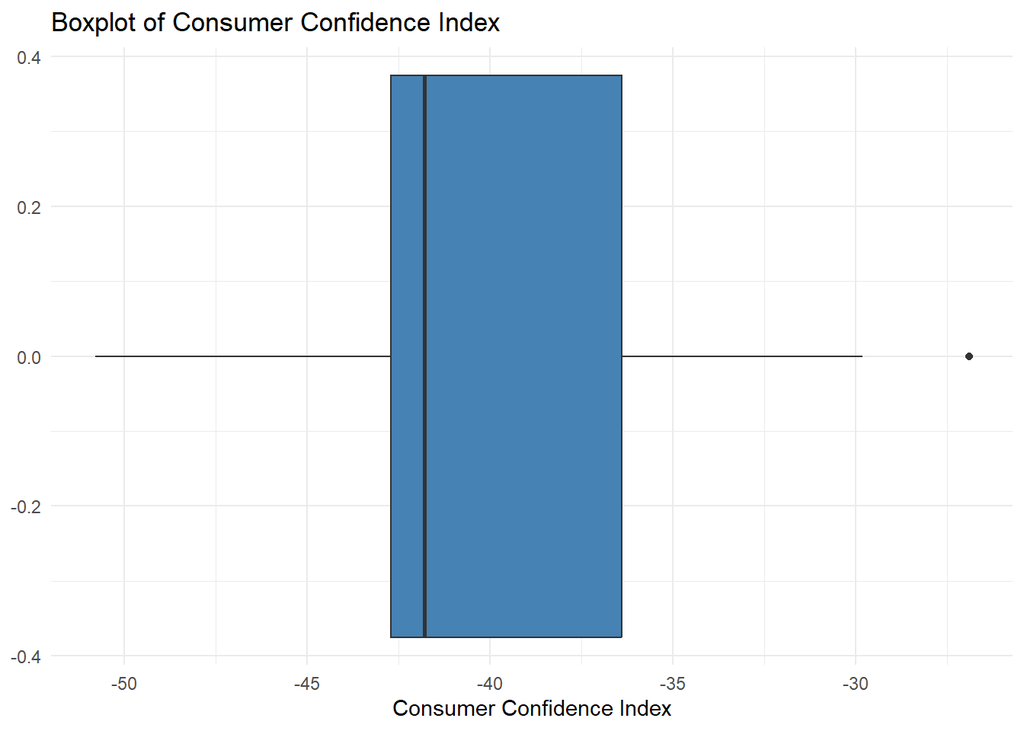

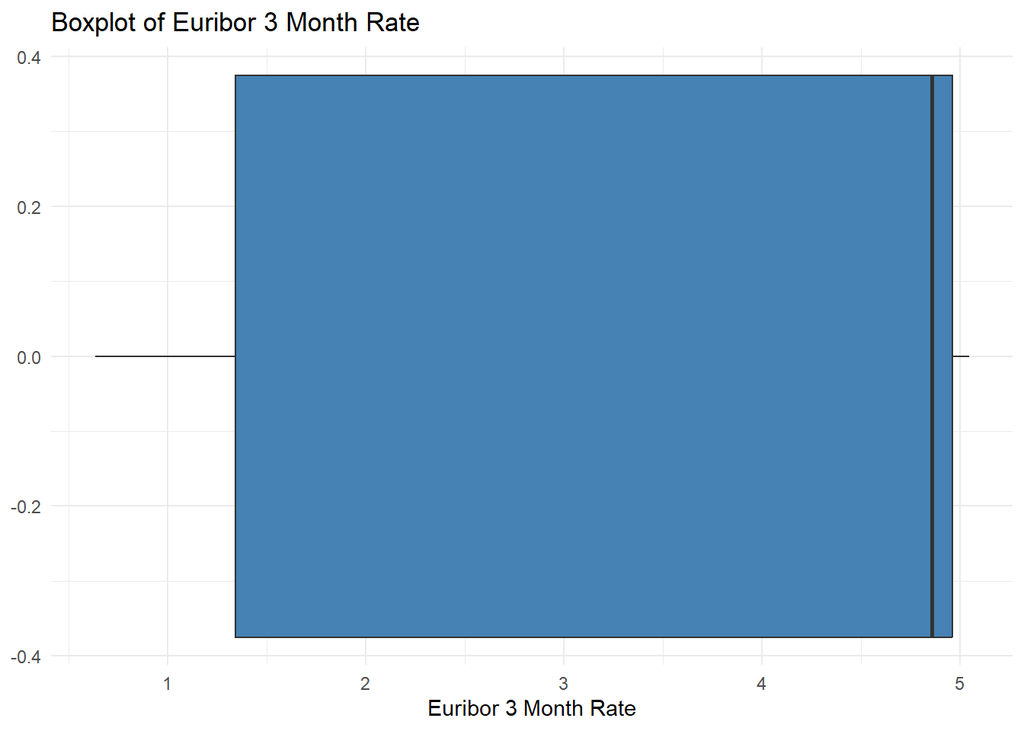

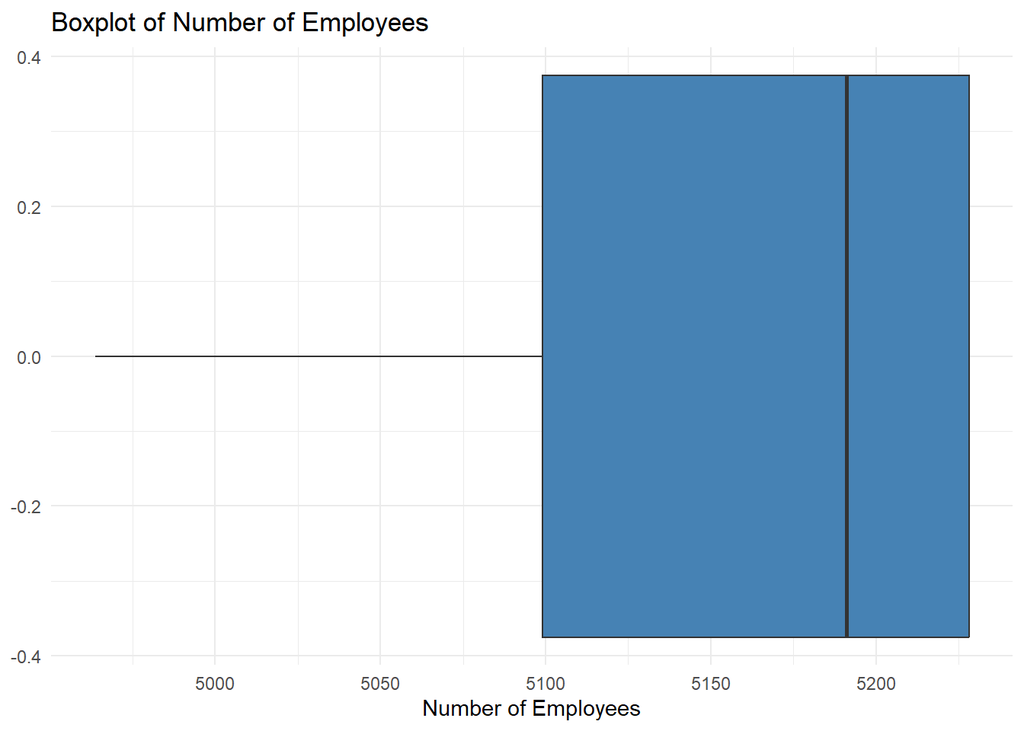

```r
for (var in num_vars) {
  p = ggplot(df, aes(y = !!sym(var))) +
    geom_boxplot(fill = "steelblue") +
    coord_flip() +
    labs(y = get_label(var), title = paste("Boxplot of", get_label(var))) +
    theme_minimal()
  print(p)
}
```

Pdays, as noted above, has a high number of 999 values, so we will be analyzing it as a boolean categorical variable rather than a numeric one.

Likewise, “previous contacts” has a high number of zeroes, with few unique values; we may consider this as a factor as well.

Employment Variation Rate and the Euribor 3-Month Rate may also be best handled as a “stealth” categorical variable.

The number of employees has so little variance that it might not bring any explanatory or predictive power to the model.

#### Transformations

```r
df = df %>%
  mutate(
    duration_log = log(duration + 1),
    campaign_log = log(campaign + 1),

    prev_contacts_binned = case_when(
      previous == 0 ~ "0",
      previous == 1 ~ "1",
      previous >= 2 ~ "2+"
    ),

    euribor_binned = case_when(
      euribor3m < 1 ~ "<1",
      euribor3m >= 5 ~ "5+",
      TRUE ~ as.character(floor(euribor3m))
    )
  )

df = df %>%
  mutate(
    prev_contacts_binned = factor(prev_contacts_binned, levels = c("0", "1", "2+")),
    euribor_binned = factor(euribor_binned, levels = c("<1", "1", "2", "3", "4", "5", "5+"))
  )

num_vars = c(num_vars, "duration_log", "campaign_log")
cat_vars = c(cat_vars, "prev_contacts_binned", "euribor_binned")

# num_vars
# cat_vars
```

We binned the number of previous contacts and Euribor values, and include them with the other categorical variables.

The call duration and number of contacts in the campaign may be useful for EDA and interpretive modeling, so we log-transform them to see if it addresses the skewness.

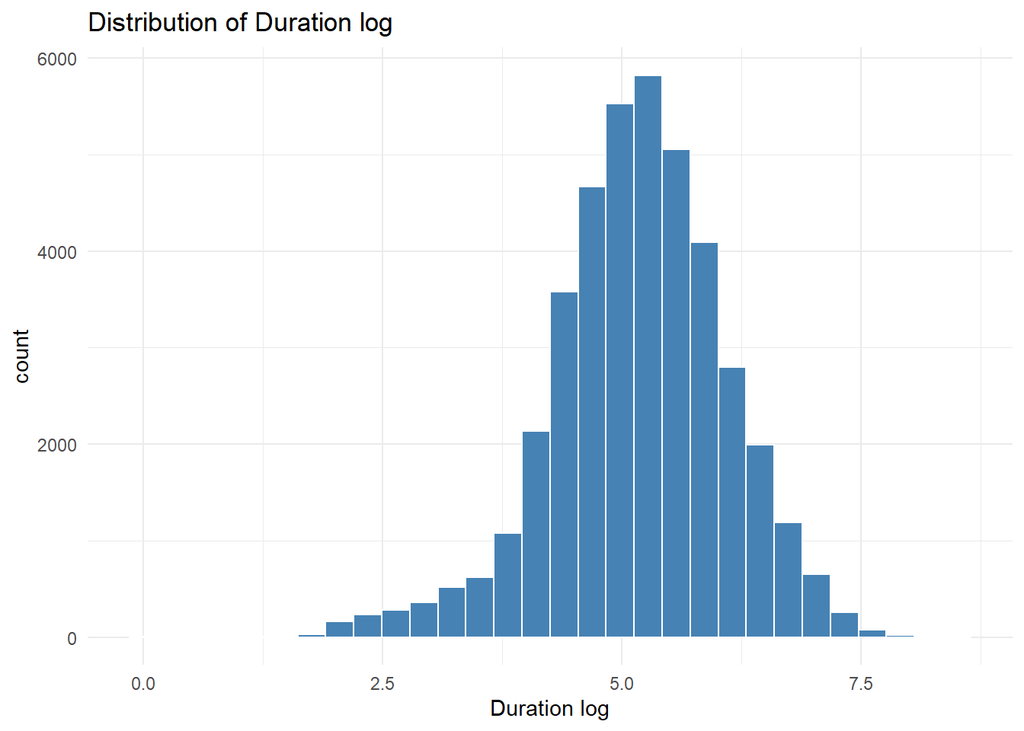

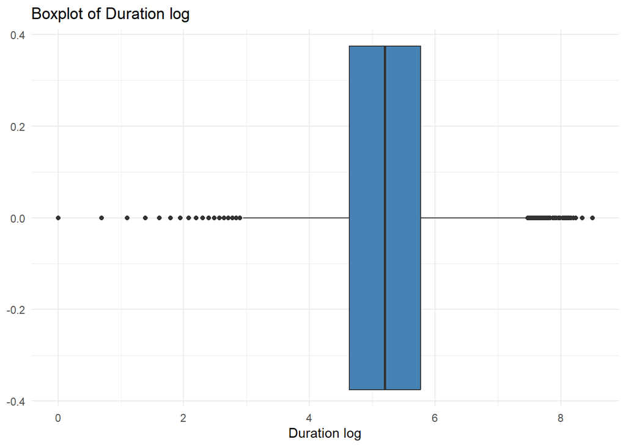

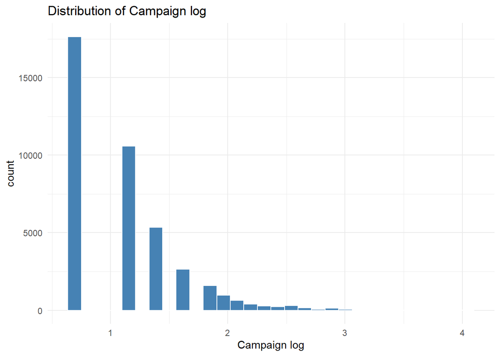

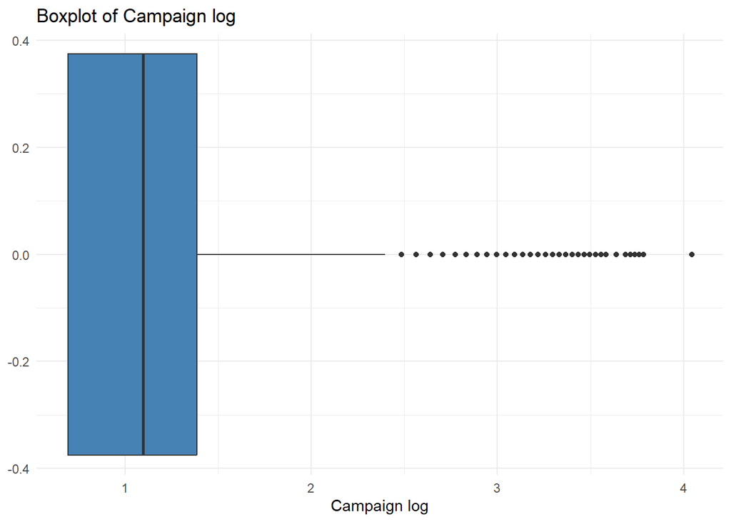

```r
log_vars = c("duration_log", "campaign_log")

for (var in log_vars) {
  p = ggplot(df, aes(x = !!sym(var))) +
    geom_histogram(fill = "steelblue", color = "white", bins = 30) +
    labs(
      x = get_label(var),
      title = paste("Distribution of", get_label(var))
    ) +
    theme_minimal()
  print(p)

  p = ggplot(df, aes(y = !!sym(var))) +
    geom_boxplot(fill = "steelblue") +
    coord_flip() +
    labs(
      y = get_label(var),
      title = paste("Boxplot of", get_label(var))
    ) +
    theme_minimal()
  print(p)
}
```

The log transformation appears to help a great deal with the skewness of duration, but has only a mild effect on the current campaign contacts. This may be another opportunity for binning, so we will look at a binned version of campaign contacts in the categorical analysis.

```r
df = df %>%
  mutate(campaign_bin = case_when(
    campaign == 1 ~ "1",
    campaign %in% 2:3 ~ "2–3",
    campaign >= 4 ~ "4+"
  )) %>%
  mutate(campaign_bin = factor(campaign_bin, levels = c("1", "2–3", "4+")))

cat_vars = c(cat_vars, "campaign_bin")
# cat_vars
```

### Categorical Variables

**Click to expand: Categorical Variable Plots**